# ANOVA In Class Activity

## 1-Way Analysis of Variance

*Diet Issues:*

The underlying linear model.

$$y_{ij} = \mu + \tau_{Diet, i} + \epsilon_j$$

Test the null hypothesis, $H_O:$ *There is no effect of diet on weight loss* (e.g., $\tau_{Diet-1} = \tau_{Diet-1} = \tau_{Diet-1} = 0.0$). Is there evidence for one diet producing more weight loss than the others? Create an `aov` analysis and assign it to the variable `fit.diet` and examine its contents.

```r
df %>%
  mutate( `Weight Loss` = (pre.weight - weight6weeks )  ) -> df

fit.diet <- aov( `Weight Loss` ~ Diet, data=df  )
anova( fit.diet )
```

```
Analysis of Variance Table

Response: Weight Loss
          Df Sum Sq Mean Sq F value   Pr(>F)
Diet       2  60.53 30.2635  5.3831 0.006596 **
Residuals 73 410.40  5.6219
---
Signif. codes:  0 ‘***’ 0.001 ‘**’ 0.01 ‘*’ 0.05 ‘.’ 0.1 ‘ ’ 1
```

Are they all significantly different? Try the `TukeyHSD()` Interpret the results.

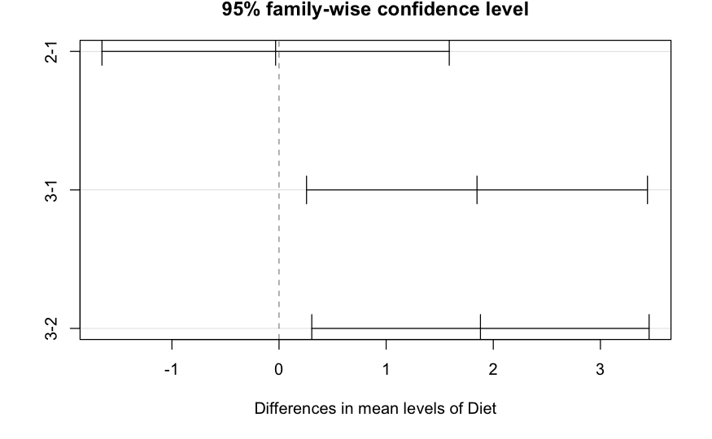

```r
tukey <- TukeyHSD( fit.diet )
plot( tukey )
```

```r
library( broom )
tidy_diet <- tidy( fit.diet )
tidy_diet
```

| term | df | sumsq | meansq | statistic | p.value |
| --- | --- | --- | --- | --- | --- |
| Diet | 2 | 60.52701 | 30.263504 | 5.383104 | 0.006595853 |
| Residuals | 73 | 410.40181 | 5.621943 | NA | NA |

Now, since it is all easily accessible, we can calculate the $R^2$ from the new model output.

```r
r2_Diet <- tidy_diet$sumsq[1] / sum( tidy_diet$sumsq )
r2_Diet
```

```
[1] 0.1285269
```

*Gender Issues:*

The underlying linear model.

$$y_{ij} = \mu + \tau_{gender, i} + \epsilon_j$$

Independent of the diet, test the null hypothesis $H_O:$ *There is no difference in weight loss between genders* (e.g., $*{gender-0} =* {gender-2} = 0.0 $). Is there evidence for one gender being significantly different than another? How much of the variation is explained (another $R^2$ by gender?

```r
fit.gender <- aov( `Weight Loss` ~ gender, data =df )
fit.gender
```

```
Call:
   aov(formula = `Weight Loss` ~ gender, data = df)

Terms:
                  gender Residuals
Sum of Squares    0.2785  470.6503
Deg. of Freedom        1        74

Residual standard error: 2.521932
Estimated effects may be unbalanced
```

```r
anova( fit.gender )
```

```
Analysis of Variance Table

Response: Weight Loss
          Df Sum Sq Mean Sq F value Pr(>F)
gender     1   0.28  0.2785  0.0438 0.8348
Residuals 74 470.65  6.3601
```

```r
summary( fit.gender)
```

```
            Df Sum Sq Mean Sq F value Pr(>F)
gender       1    0.3   0.278   0.044  0.835
Residuals   74  470.7   6.360
```

```r
tidy_gender <- tidy( fit.gender )
R2_gender <- tidy_gender$sumsq[1] / ( sum( tidy_gender$sumsq) )
R2_gender
```

```
[1] 0.0005913517
```

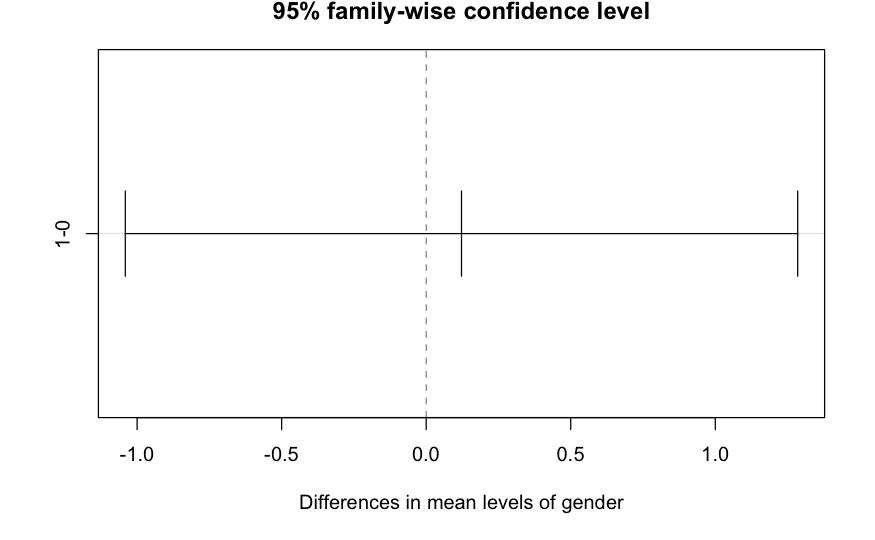

```r
tukey_gender <- TukeyHSD(fit.gender )
plot( tukey_gender )
```

How do you interpret these results thus far?

# Do genders respond differently to diets?

$$y_{ijk} = \mu + \tau_{Diet,i} + \tau_{gender,j} + \epsilon_k$$

So here we do something a bit different. We want to simultaneously ask the following questions:

- Do diets influence weight loss?
- Do genders influence weight loss?
- Is there an interaction where different genders respond differently to different diets?

In $R$, this is done as:

```r
fit.both <- aov( `Weight Loss` ~ Diet*gender, data=df )
fit.both
```

```
Call:
   aov(formula = `Weight Loss` ~ Diet * gender, data = df)

Terms:
                    Diet   gender Diet:gender Residuals
Sum of Squares   60.5270   0.1687     33.9041  376.3290
Deg. of Freedom        2        1           2        70

Residual standard error: 2.318648
Estimated effects may be unbalanced
```

```r
anova(fit.both)
```

```
Analysis of Variance Table

Response: Weight Loss
            Df Sum Sq Mean Sq F value   Pr(>F)
Diet         2  60.53 30.2635  5.6292 0.005408 **
gender       1   0.17  0.1687  0.0314 0.859910
Diet:gender  2  33.90 16.9520  3.1532 0.048842 *
Residuals   70 376.33  5.3761
---
Signif. codes:  0 ‘***’ 0.001 ‘**’ 0.01 ‘*’ 0.05 ‘.’ 0.1 ‘ ’ 1
```

```r
tukey.both <- TukeyHSD( fit.both )
tukey.both
```

```
  Tukey multiple comparisons of means
    95% family-wise confidence level

Fit: aov(formula = `Weight Loss` ~ Diet * gender, data = df)

$Diet
         diff        lwr      upr     p adj
2-1 -0.032000 -1.6186577 1.554658 0.9987150
3-1  1.848148  0.2905393 3.405757 0.0160200
3-2  1.880148  0.3391199 3.421176 0.0128543

$gender
          diff        lwr     upr     p adj
1-0 0.09502529 -0.9751891 1.16524 0.8599508

$`Diet:gender`
              diff        lwr       upr     p adj
2:0-1:0 -0.4428571 -3.0107291 2.1250148 0.9958151
3:0-1:0  2.8300000  0.3052886 5.3547114 0.0191170
1:1-1:0  0.6000000 -2.2129628 3.4129628 0.9887997
2:1-1:0  1.0590909 -1.6782698 3.7964516 0.8656520
3:1-1:0  1.1833333 -1.4893925 3.8560592 0.7855223
3:0-2:0  3.2728571  0.7481458 5.7975685 0.0040103
1:1-2:0  1.0428571 -1.7701056 3.8558199 0.8852416
2:1-2:0  1.5019481 -1.2354126 4.2393087 0.5963201
3:1-2:0  1.6261905 -1.0465354 4.2989163 0.4833188
1:1-3:0 -2.2300000 -5.0036187 0.5436187 0.1863470
2:1-3:0 -1.7709091 -4.4678230 0.9260048 0.3965102
3:1-3:0 -1.6466667 -4.2779524 0.9846191 0.4513580
2:1-1:1  0.4590909 -2.5093998 3.4275816 0.9975014
3:1-1:1  0.5833333 -2.3256625 3.4923292 0.9915569
3:1-2:1  0.1242424 -2.7117126 2.9601974 0.9999949
```

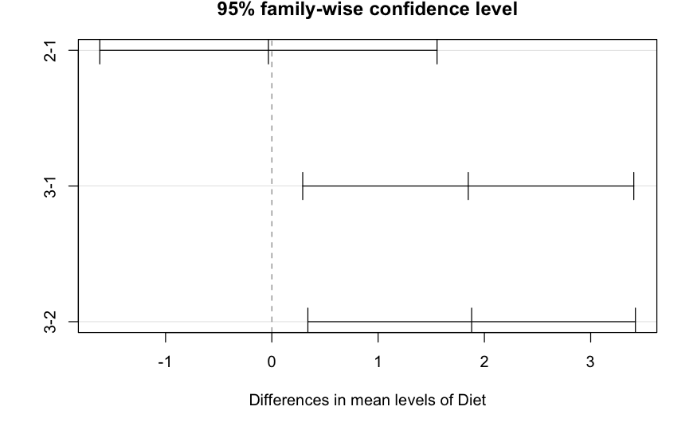

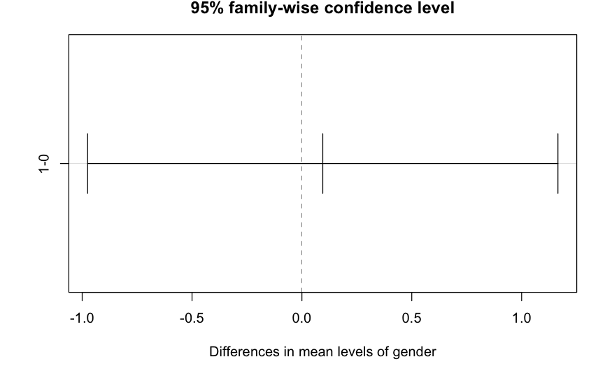

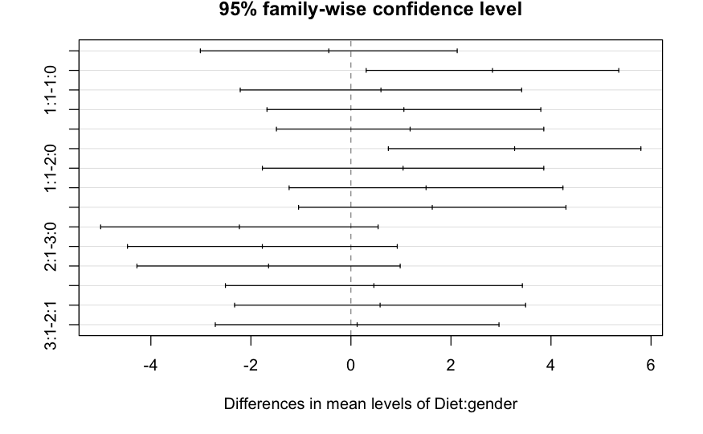

```r
plot( tukey.both)
```

What is the $R^2$ for this model?

```r
tidy_both <- tidy( fit.both )
tidy_both$sumsq[1] / sum( tidy_both$sumsq )
```

```
[1] 0.1285269
```

# Which Model is Best?

How would you compare the models you generated? How do you interpret the findings?